# Risk Factor Analysis

## Outcome Variable

**Outcome Variable:** stunted

## Predictor Variables

**Intervention Variable:** meducyrs

**Adjustment Set:**

- arm
- W_mage
- feducyrs
- hhwealth_quart
- W_mhtcm
- W_mwtkg
- W_mbmi
- W_gagebrth
- W_birthwt
- W_birthlen
- single
- W_nrooms
- impsan
- delta_W_mage
- delta_feducyrs
- delta_hhwealth_quart
- delta_W_mhtcm
- delta_W_mwtkg
- delta_W_mbmi
- delta_W_gagebrth
- delta_W_birthwt
- delta_W_birthlen
- delta_single
- delta_W_nrooms
- delta_impsan

## Stratifying Variables

The analysis was stratified on these variable(s):

- agecat
- studyid
- country

## Data Summary

| agecat | studyid | country | meducyrs | stunted | n_cell | n |
| --- | --- | --- | --- | --- | --- | --- |
| Birth | ki0047075b-MAL-ED | BANGLADESH | High | 0 | 59 | 187 |
| Birth | ki0047075b-MAL-ED | BANGLADESH | High | 1 | 8 | 187 |
| Birth | ki0047075b-MAL-ED | BANGLADESH | Low | 0 | 47 | 187 |
| Birth | ki0047075b-MAL-ED | BANGLADESH | Low | 1 | 18 | 187 |
| Birth | ki0047075b-MAL-ED | BANGLADESH | Medium | 0 | 47 | 187 |
| Birth | ki0047075b-MAL-ED | BANGLADESH | Medium | 1 | 8 | 187 |
| Birth | ki0047075b-MAL-ED | BRAZIL | High | 0 | 18 | 65 |
| Birth | ki0047075b-MAL-ED | BRAZIL | High | 1 | 0 | 65 |
| Birth | ki0047075b-MAL-ED | BRAZIL | Low | 0 | 14 | 65 |
| Birth | ki0047075b-MAL-ED | BRAZIL | Low | 1 | 3 | 65 |
| Birth | ki0047075b-MAL-ED | BRAZIL | Medium | 0 | 24 | 65 |
| Birth | ki0047075b-MAL-ED | BRAZIL | Medium | 1 | 6 | 65 |
| Birth | ki0047075b-MAL-ED | INDIA | High | 0 | 7 | 40 |
| Birth | ki0047075b-MAL-ED | INDIA | High | 1 | 1 | 40 |
| Birth | ki0047075b-MAL-ED | INDIA | Low | 0 | 17 | 40 |
| Birth | ki0047075b-MAL-ED | INDIA | Low | 1 | 1 | 40 |
| Birth | ki0047075b-MAL-ED | INDIA | Medium | 0 | 8 | 40 |
| Birth | ki0047075b-MAL-ED | INDIA | Medium | 1 | 6 | 40 |
| Birth | ki0047075b-MAL-ED | NEPAL | High | 0 | 5 | 25 |
| Birth | ki0047075b-MAL-ED | NEPAL | High | 1 | 0 | 25 |
| Birth | ki0047075b-MAL-ED | NEPAL | Low | 0 | 12 | 25 |
| Birth | ki0047075b-MAL-ED | NEPAL | Low | 1 | 0 | 25 |
| Birth | ki0047075b-MAL-ED | NEPAL | Medium | 0 | 6 | 25 |
| Birth | ki0047075b-MAL-ED | NEPAL | Medium | 1 | 2 | 25 |
| Birth | ki0047075b-MAL-ED | PERU | High | 0 | 60 | 233 |
| Birth | ki0047075b-MAL-ED | PERU | High | 1 | 8 | 233 |
| Birth | ki0047075b-MAL-ED | PERU | Low | 0 | 72 | 233 |
| Birth | ki0047075b-MAL-ED | PERU | Low | 1 | 12 | 233 |
| Birth | ki0047075b-MAL-ED | PERU | Medium | 0 | 75 | 233 |
| Birth | ki0047075b-MAL-ED | PERU | Medium | 1 | 6 | 233 |

[output cut: 396 more lines]

The following strata were considered:

- agecat: 24 months, studyid: ki0047075b-MAL-ED, country: BANGLADESH
- agecat: 24 months, studyid: ki0047075b-MAL-ED, country: BRAZIL
- agecat: 24 months, studyid: ki0047075b-MAL-ED, country: INDIA
- agecat: 24 months, studyid: ki0047075b-MAL-ED, country: NEPAL
- agecat: 24 months, studyid: ki0047075b-MAL-ED, country: PERU
- agecat: 24 months, studyid: ki0047075b-MAL-ED, country: SOUTH AFRICA
- agecat: 24 months, studyid: ki0047075b-MAL-ED, country: TANZANIA, UNITED REPUBLIC OF
- agecat: 24 months, studyid: ki1000108-CMC-V-BCS-2002, country: INDIA
- agecat: 24 months, studyid: ki1000108-IRC, country: INDIA
- agecat: 24 months, studyid: ki1000109-EE, country: PAKISTAN
- agecat: 24 months, studyid: ki1017093-NIH-Birth, country: BANGLADESH
- agecat: 24 months, studyid: ki1017093b-PROVIDE, country: BANGLADESH
- agecat: 24 months, studyid: ki1017093c-NIH-Crypto, country: BANGLADESH
- agecat: 24 months, studyid: ki1066203-TanzaniaChild2, country: TANZANIA, UNITED REPUBLIC OF
- agecat: 24 months, studyid: ki1113344-GMS-Nepal, country: NEPAL
- agecat: 24 months, studyid: ki1119695-PROBIT, country: BELARUS
- agecat: 24 months, studyid: ki1126311-ZVITAMBO, country: ZIMBABWE
- agecat: 24 months, studyid: ki1135781-COHORTS, country: GUATEMALA
- agecat: 24 months, studyid: ki1135781-COHORTS, country: INDIA
- agecat: 24 months, studyid: ki1135781-COHORTS, country: PHILIPPINES
- agecat: 24 months, studyid: ki1148112-LCNI-5, country: MALAWI
- agecat: 24 months, studyid: kiGH5241-JiVitA-3, country: BANGLADESH
- agecat: 24 months, studyid: kiGH5241-JiVitA-4, country: BANGLADESH
- agecat: 6 months, studyid: ki0047075b-MAL-ED, country: BANGLADESH
- agecat: 6 months, studyid: ki0047075b-MAL-ED, country: BRAZIL
- agecat: 6 months, studyid: ki0047075b-MAL-ED, country: INDIA
- agecat: 6 months, studyid: ki0047075b-MAL-ED, country: NEPAL
- agecat: 6 months, studyid: ki0047075b-MAL-ED, country: PERU
- agecat: 6 months, studyid: ki0047075b-MAL-ED, country: SOUTH AFRICA
- agecat: 6 months, studyid: ki0047075b-MAL-ED, country: TANZANIA, UNITED REPUBLIC OF
- agecat: 6 months, studyid: ki1000108-CMC-V-BCS-2002, country: INDIA
- agecat: 6 months, studyid: ki1000108-IRC, country: INDIA
- agecat: 6 months, studyid: ki1000109-EE, country: PAKISTAN
- agecat: 6 months, studyid: ki1000304b-SAS-CompFeed, country: INDIA
- agecat: 6 months, studyid: ki1000304b-SAS-FoodSuppl, country: INDIA
- agecat: 6 months, studyid: ki1017093-NIH-Birth, country: BANGLADESH
- agecat: 6 months, studyid: ki1017093b-PROVIDE, country: BANGLADESH
- agecat: 6 months, studyid: ki1017093c-NIH-Crypto, country: BANGLADESH
- agecat: 6 months, studyid: ki1066203-TanzaniaChild2, country: TANZANIA, UNITED REPUBLIC OF
- agecat: 6 months, studyid: ki1112895-Guatemala BSC, country: GUATEMALA
- agecat: 6 months, studyid: ki1113344-GMS-Nepal, country: NEPAL
- agecat: 6 months, studyid: ki1119695-PROBIT, country: BELARUS
- agecat: 6 months, studyid: ki1126311-ZVITAMBO, country: ZIMBABWE
- agecat: 6 months, studyid: ki1135781-COHORTS, country: GUATEMALA
- agecat: 6 months, studyid: ki1135781-COHORTS, country: INDIA
- agecat: 6 months, studyid: ki1135781-COHORTS, country: PHILIPPINES
- agecat: 6 months, studyid: ki1148112-LCNI-5, country: MALAWI
- agecat: 6 months, studyid: kiGH5241-JiVitA-3, country: BANGLADESH
- agecat: 6 months, studyid: kiGH5241-JiVitA-4, country: BANGLADESH
- agecat: Birth, studyid: ki0047075b-MAL-ED, country: BANGLADESH
- agecat: Birth, studyid: ki0047075b-MAL-ED, country: BRAZIL
- agecat: Birth, studyid: ki0047075b-MAL-ED, country: INDIA
- agecat: Birth, studyid: ki0047075b-MAL-ED, country: NEPAL
- agecat: Birth, studyid: ki0047075b-MAL-ED, country: PERU
- agecat: Birth, studyid: ki0047075b-MAL-ED, country: SOUTH AFRICA
- agecat: Birth, studyid: ki0047075b-MAL-ED, country: TANZANIA, UNITED REPUBLIC OF
- agecat: Birth, studyid: ki1000108-CMC-V-BCS-2002, country: INDIA
- agecat: Birth, studyid: ki1000108-IRC, country: INDIA
- agecat: Birth, studyid: ki1000109-EE, country: PAKISTAN
- agecat: Birth, studyid: ki1000304b-SAS-CompFeed, country: INDIA
- agecat: Birth, studyid: ki1017093-NIH-Birth, country: BANGLADESH
- agecat: Birth, studyid: ki1017093b-PROVIDE, country: BANGLADESH
- agecat: Birth, studyid: ki1017093c-NIH-Crypto, country: BANGLADESH
- agecat: Birth, studyid: ki1113344-GMS-Nepal, country: NEPAL
- agecat: Birth, studyid: ki1119695-PROBIT, country: BELARUS
- agecat: Birth, studyid: ki1126311-ZVITAMBO, country: ZIMBABWE
- agecat: Birth, studyid: ki1135781-COHORTS, country: GUATEMALA
- agecat: Birth, studyid: ki1135781-COHORTS, country: INDIA
- agecat: Birth, studyid: ki1135781-COHORTS, country: PHILIPPINES
- agecat: Birth, studyid: kiGH5241-JiVitA-3, country: BANGLADESH
- agecat: Birth, studyid: kiGH5241-JiVitA-4, country: BANGLADESH

### Dropped Strata

Some strata were dropped due to rare outcomes:

- agecat: Birth, studyid: ki0047075b-MAL-ED, country: BRAZIL
- agecat: Birth, studyid: ki0047075b-MAL-ED, country: INDIA
- agecat: Birth, studyid: ki0047075b-MAL-ED, country: NEPAL
- agecat: Birth, studyid: ki0047075b-MAL-ED, country: SOUTH AFRICA
- agecat: Birth, studyid: ki0047075b-MAL-ED, country: TANZANIA, UNITED REPUBLIC OF
- agecat: Birth, studyid: ki1000108-CMC-V-BCS-2002, country: INDIA
- agecat: Birth, studyid: ki1000109-EE, country: PAKISTAN
- agecat: Birth, studyid: ki1119695-PROBIT, country: BELARUS
- agecat: 6 months, studyid: ki0047075b-MAL-ED, country: BRAZIL
- agecat: 6 months, studyid: ki0047075b-MAL-ED, country: NEPAL
- agecat: 6 months, studyid: ki0047075b-MAL-ED, country: TANZANIA, UNITED REPUBLIC OF
- agecat: 6 months, studyid: ki1000109-EE, country: PAKISTAN
- agecat: 24 months, studyid: ki0047075b-MAL-ED, country: BRAZIL
- agecat: 24 months, studyid: ki0047075b-MAL-ED, country: TANZANIA, UNITED REPUBLIC OF
- agecat: 24 months, studyid: ki1000109-EE, country: PAKISTAN
- agecat: 24 months, studyid: ki1066203-TanzaniaChild2, country: TANZANIA, UNITED REPUBLIC OF

## Methods Detail

We’re interested in the causal parameters $E[Y_a]$ for all values of $a \in \mathcal{A}$. These parameters represent the mean outcome if, possibly contrary to fact, we intervened to set all units to have $A=a$. Under the randomization and positivity assumptions, these are identified by the statistical parameters $\psi_a=E_W[E_{Y|A,W}(Y|A=a,W)]$. In addition, we’re interested in the mean of $Y$, $E[Y]$ under no intervention (the observed mean). We will estimate these parameters by using SuperLearner to fit the relevant likelihood factors – $E_{Y|A,W}(Y|A=a,W)$ and $p(A=a|W)$, and then updating our likelihood fit using a joint TMLE.

For unadjusted analyses ($W=\{\}$), initial likelihoods were estimated using Lrnr_glm to estimate the simple $E(Y|A)$ and Lrnr_mean to estimate $p(A)$. For adjusted analyses, a small library containing Lrnr_glmnet, Lrnr_xgboost, and Lrnr_mean was used.

Having estimated these parameters, we will then use the delta method to estimate relative risks and attributable risks relative to a prespecified baseline level of $A$.

# Results Detail

## Results Plots

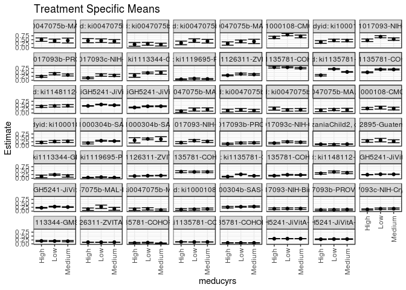

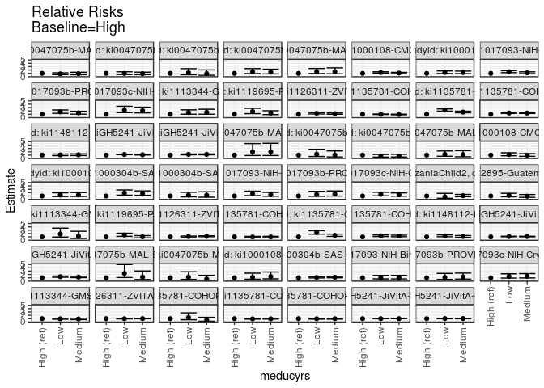

[figure not shown]

[figure not shown]

## Results Table

### Parameter: TSM

| agecat | studyid | country | intervention_level | baseline_level | estimate | ci_lower | ci_upper |
| --- | --- | --- | --- | --- | --- | --- | --- |
| Birth | ki0047075b-MAL-ED | BANGLADESH | High | NA | 0.1194030 | 0.0415507 | 0.1972552 |
| Birth | ki0047075b-MAL-ED | BANGLADESH | Low | NA | 0.2769231 | 0.1678475 | 0.3859987 |
| Birth | ki0047075b-MAL-ED | BANGLADESH | Medium | NA | 0.1454545 | 0.0520297 | 0.2388794 |
| Birth | ki0047075b-MAL-ED | PERU | High | NA | 0.1176471 | 0.0409040 | 0.1943902 |
| Birth | ki0047075b-MAL-ED | PERU | Low | NA | 0.1428571 | 0.0678643 | 0.2178500 |
| Birth | ki0047075b-MAL-ED | PERU | Medium | NA | 0.0740741 | 0.0169182 | 0.1312299 |
| Birth | ki1000108-IRC | INDIA | High | NA | 0.1010307 | 0.0459775 | 0.1560839 |
| Birth | ki1000108-IRC | INDIA | Low | NA | 0.1185931 | 0.0657047 | 0.1714814 |
| Birth | ki1000108-IRC | INDIA | Medium | NA | 0.1381164 | 0.0796207 | 0.1966120 |
| Birth | ki1000304b-SAS-CompFeed | INDIA | High | NA | 0.2522964 | 0.2023069 | 0.3022860 |
| Birth | ki1000304b-SAS-CompFeed | INDIA | Low | NA | 0.2775917 | 0.2486521 | 0.3065314 |
| Birth | ki1000304b-SAS-CompFeed | INDIA | Medium | NA | 0.2931071 | 0.2544455 | 0.3317687 |
| Birth | ki1017093-NIH-Birth | BANGLADESH | High | NA | 0.1520193 | 0.0972582 | 0.2067803 |
| Birth | ki1017093-NIH-Birth | BANGLADESH | Low | NA | 0.1624285 | 0.1136702 | 0.2111869 |
| Birth | ki1017093-NIH-Birth | BANGLADESH | Medium | NA | 0.1624642 | 0.1107643 | 0.2141641 |
| Birth | ki1017093b-PROVIDE | BANGLADESH | High | NA | 0.0826335 | 0.0384423 | 0.1268247 |
| Birth | ki1017093b-PROVIDE | BANGLADESH | Low | NA | 0.0915547 | 0.0454636 | 0.1376457 |
| Birth | ki1017093b-PROVIDE | BANGLADESH | Medium | NA | 0.1003023 | 0.0578646 | 0.1427400 |
| Birth | ki1017093c-NIH-Crypto | BANGLADESH | High | NA | 0.1069578 | 0.0708724 | 0.1430431 |
| Birth | ki1017093c-NIH-Crypto | BANGLADESH | Low | NA | 0.1518765 | 0.1077383 | 0.1960148 |
| Birth | ki1017093c-NIH-Crypto | BANGLADESH | Medium | NA | 0.1566073 | 0.1125142 | 0.2007003 |
| Birth | ki1113344-GMS-Nepal | NEPAL | High | NA | 0.1854364 | 0.1512696 | 0.2196032 |
| Birth | ki1113344-GMS-Nepal | NEPAL | Low | NA | 0.1767243 | 0.1472055 | 0.2062431 |
| Birth | ki1113344-GMS-Nepal | NEPAL | Medium | NA | 0.1686013 | 0.1284447 | 0.2087580 |
| Birth | ki1126311-ZVITAMBO | ZIMBABWE | High | NA | 0.1032709 | 0.0978013 | 0.1087406 |
| Birth | ki1126311-ZVITAMBO | ZIMBABWE | Low | NA | 0.1020369 | 0.0954657 | 0.1086080 |
| Birth | ki1126311-ZVITAMBO | ZIMBABWE | Medium | NA | 0.1054984 | 0.0993255 | 0.1116713 |
| Birth | ki1135781-COHORTS | GUATEMALA | High | NA | 0.0561798 | 0.0223319 | 0.0900276 |
| Birth | ki1135781-COHORTS | GUATEMALA | Low | NA | 0.0767263 | 0.0503293 | 0.1031234 |
| Birth | ki1135781-COHORTS | GUATEMALA | Medium | NA | 0.0329670 | 0.0117744 | 0.0541597 |

[output cut: 135 more lines]

### Parameter: E(Y)

| agecat | studyid | country | intervention_level | baseline_level | estimate | ci_lower | ci_upper |
| --- | --- | --- | --- | --- | --- | --- | --- |
| Birth | ki0047075b-MAL-ED | BANGLADESH | NA | NA | 0.1818182 | 0.1263894 | 0.2372469 |
| Birth | ki0047075b-MAL-ED | PERU | NA | NA | 0.1115880 | 0.0710726 | 0.1521034 |
| Birth | ki1000108-IRC | INDIA | NA | NA | 0.1159794 | 0.0840777 | 0.1478811 |
| Birth | ki1000304b-SAS-CompFeed | INDIA | NA | NA | 0.2787540 | 0.2475949 | 0.3099131 |
| Birth | ki1017093-NIH-Birth | BANGLADESH | NA | NA | 0.1595395 | 0.1304091 | 0.1886699 |
| Birth | ki1017093b-PROVIDE | BANGLADESH | NA | NA | 0.0890538 | 0.0649864 | 0.1131212 |
| Birth | ki1017093c-NIH-Crypto | BANGLADESH | NA | NA | 0.1379781 | 0.1129774 | 0.1629789 |
| Birth | ki1113344-GMS-Nepal | NEPAL | NA | NA | 0.1760462 | 0.1476696 | 0.2044227 |
| Birth | ki1126311-ZVITAMBO | ZIMBABWE | NA | NA | 0.1035005 | 0.0984282 | 0.1085729 |
| Birth | ki1135781-COHORTS | GUATEMALA | NA | NA | 0.0581948 | 0.0423724 | 0.0740172 |
| Birth | ki1135781-COHORTS | INDIA | NA | NA | 0.1182899 | 0.1095248 | 0.1270550 |
| Birth | ki1135781-COHORTS | PHILIPPINES | NA | NA | 0.0613115 | 0.0527962 | 0.0698268 |
| Birth | kiGH5241-JiVitA-3 | BANGLADESH | NA | NA | 0.3290676 | 0.3216916 | 0.3364437 |
| Birth | kiGH5241-JiVitA-4 | BANGLADESH | NA | NA | 0.3035144 | 0.2834906 | 0.3235382 |
| 6 months | ki0047075b-MAL-ED | BANGLADESH | NA | NA | 0.1785714 | 0.1248161 | 0.2323268 |
| 6 months | ki0047075b-MAL-ED | INDIA | NA | NA | 0.1682692 | 0.1173060 | 0.2192324 |
| 6 months | ki0047075b-MAL-ED | PERU | NA | NA | 0.2205882 | 0.1712211 | 0.2699554 |
| 6 months | ki0047075b-MAL-ED | SOUTH AFRICA | NA | NA | 0.1968504 | 0.1478551 | 0.2458457 |
| 6 months | ki1000108-CMC-V-BCS-2002 | INDIA | NA | NA | 0.3008130 | 0.2539566 | 0.3476694 |
| 6 months | ki1000108-IRC | INDIA | NA | NA | 0.2457002 | 0.2038248 | 0.2875757 |
| 6 months | ki1000304b-SAS-CompFeed | INDIA | NA | NA | 0.2844311 | 0.2666491 | 0.3022132 |
| 6 months | ki1000304b-SAS-FoodSuppl | INDIA | NA | NA | 0.4289474 | 0.3791199 | 0.4787748 |
| 6 months | ki1017093-NIH-Birth | BANGLADESH | NA | NA | 0.2681564 | 0.2306532 | 0.3056597 |
| 6 months | ki1017093b-PROVIDE | BANGLADESH | NA | NA | 0.1589404 | 0.1297581 | 0.1881227 |
| 6 months | ki1017093c-NIH-Crypto | BANGLADESH | NA | NA | 0.2097902 | 0.1799252 | 0.2396552 |
| 6 months | ki1066203-TanzaniaChild2 | TANZANIA, UNITED REPUBLIC OF | NA | NA | 0.0964869 | 0.0836111 | 0.1093627 |
| 6 months | ki1112895-Guatemala BSC | GUATEMALA | NA | NA | 0.3104693 | 0.2558835 | 0.3650551 |
| 6 months | ki1113344-GMS-Nepal | NEPAL | NA | NA | 0.2174688 | 0.1833021 | 0.2516355 |
| 6 months | ki1119695-PROBIT | BELARUS | NA | NA | 0.0626864 | 0.0488489 | 0.0765238 |
| 6 months | ki1126311-ZVITAMBO | ZIMBABWE | NA | NA | 0.1631427 | 0.1553579 | 0.1709275 |
| 6 months | ki1135781-COHORTS | GUATEMALA | NA | NA | 0.4075630 | 0.3763327 | 0.4387933 |
| 6 months | ki1135781-COHORTS | INDIA | NA | NA | 0.1915758 | 0.1810911 | 0.2020606 |
| 6 months | ki1135781-COHORTS | PHILIPPINES | NA | NA | 0.2112260 | 0.1958496 | 0.2266024 |
| 6 months | ki1148112-LCNI-5 | MALAWI | NA | NA | 0.3628536 | 0.3297820 | 0.3959252 |
| 6 months | kiGH5241-JiVitA-3 | BANGLADESH | NA | NA | 0.2514589 | 0.2433251 | 0.2595926 |
| 6 months | kiGH5241-JiVitA-4 | BANGLADESH | NA | NA | 0.2525944 | 0.2385189 | 0.2666699 |
| 24 months | ki0047075b-MAL-ED | BANGLADESH | NA | NA | 0.4619883 | 0.3870446 | 0.5369320 |
| 24 months | ki0047075b-MAL-ED | INDIA | NA | NA | 0.4170854 | 0.3484054 | 0.4857655 |
| 24 months | ki0047075b-MAL-ED | NEPAL | NA | NA | 0.2112676 | 0.1563184 | 0.2662168 |
| 24 months | ki0047075b-MAL-ED | PERU | NA | NA | 0.3700000 | 0.3029201 | 0.4370799 |
| 24 months | ki0047075b-MAL-ED | SOUTH AFRICA | NA | NA | 0.3529412 | 0.2921001 | 0.4137823 |
| 24 months | ki1000108-CMC-V-BCS-2002 | INDIA | NA | NA | 0.7169811 | 0.6710815 | 0.7628807 |
| 24 months | ki1000108-IRC | INDIA | NA | NA | 0.4205379 | 0.3726382 | 0.4684376 |
| 24 months | ki1017093-NIH-Birth | BANGLADESH | NA | NA | 0.5687646 | 0.5218455 | 0.6156837 |
| 24 months | ki1017093b-PROVIDE | BANGLADESH | NA | NA | 0.3287197 | 0.2903909 | 0.3670485 |
| 24 months | ki1017093c-NIH-Crypto | BANGLADESH | NA | NA | 0.2568093 | 0.2190047 | 0.2946140 |
| 24 months | ki1113344-GMS-Nepal | NEPAL | NA | NA | 0.4515464 | 0.4072114 | 0.4958814 |
| 24 months | ki1119695-PROBIT | BELARUS | NA | NA | 0.0852540 | 0.0554439 | 0.1150642 |
| 24 months | ki1126311-ZVITAMBO | ZIMBABWE | NA | NA | 0.3471629 | 0.3241082 | 0.3702176 |
| 24 months | ki1135781-COHORTS | GUATEMALA | NA | NA | 0.8107852 | 0.7871616 | 0.8344089 |
| 24 months | ki1135781-COHORTS | INDIA | NA | NA | 0.5531205 | 0.5380793 | 0.5681618 |
| 24 months | ki1135781-COHORTS | PHILIPPINES | NA | NA | 0.6229039 | 0.6036892 | 0.6421186 |
| 24 months | ki1148112-LCNI-5 | MALAWI | NA | NA | 0.4405594 | 0.3998393 | 0.4812796 |
| 24 months | kiGH5241-JiVitA-3 | BANGLADESH | NA | NA | 0.4911263 | 0.4780235 | 0.5042291 |
| 24 months | kiGH5241-JiVitA-4 | BANGLADESH | NA | NA | 0.4013921 | 0.3844229 | 0.4183613 |

### Parameter: RR

| agecat | studyid | country | intervention_level | baseline_level | estimate | ci_lower | ci_upper |
| --- | --- | --- | --- | --- | --- | --- | --- |
| Birth | ki0047075b-MAL-ED | BANGLADESH | High | High | 1.0000000 | 1.0000000 | 1.000000 |
| Birth | ki0047075b-MAL-ED | BANGLADESH | Low | High | 2.3192308 | 1.0827284 | 4.967849 |
| Birth | ki0047075b-MAL-ED | BANGLADESH | Medium | High | 1.2181818 | 0.4877850 | 3.042256 |
| Birth | ki0047075b-MAL-ED | PERU | High | High | 1.0000000 | 1.0000000 | 1.000000 |
| Birth | ki0047075b-MAL-ED | PERU | Low | High | 1.2142857 | 0.5256316 | 2.805177 |
| Birth | ki0047075b-MAL-ED | PERU | Medium | High | 0.6296296 | 0.2292335 | 1.729387 |
| Birth | ki1000108-IRC | INDIA | High | High | 1.0000000 | 1.0000000 | 1.000000 |
| Birth | ki1000108-IRC | INDIA | Low | High | 1.1738320 | 0.5797257 | 2.376782 |
| Birth | ki1000108-IRC | INDIA | Medium | High | 1.3670731 | 0.6846124 | 2.729849 |
| Birth | ki1000304b-SAS-CompFeed | INDIA | High | High | 1.0000000 | 1.0000000 | 1.000000 |
| Birth | ki1000304b-SAS-CompFeed | INDIA | Low | High | 1.1002603 | 0.9523376 | 1.271159 |
| Birth | ki1000304b-SAS-CompFeed | INDIA | Medium | High | 1.1617567 | 0.9969485 | 1.353810 |
| Birth | ki1017093-NIH-Birth | BANGLADESH | High | High | 1.0000000 | 1.0000000 | 1.000000 |
| Birth | ki1017093-NIH-Birth | BANGLADESH | Low | High | 1.0684734 | 0.6687300 | 1.707169 |
| Birth | ki1017093-NIH-Birth | BANGLADESH | Medium | High | 1.0687080 | 0.6606763 | 1.728739 |
| Birth | ki1017093b-PROVIDE | BANGLADESH | High | High | 1.0000000 | 1.0000000 | 1.000000 |
| Birth | ki1017093b-PROVIDE | BANGLADESH | Low | High | 1.1079606 | 0.5310842 | 2.311454 |
| Birth | ki1017093b-PROVIDE | BANGLADESH | Medium | High | 1.2138208 | 0.6133941 | 2.401981 |
| Birth | ki1017093c-NIH-Crypto | BANGLADESH | High | High | 1.0000000 | 1.0000000 | 1.000000 |
| Birth | ki1017093c-NIH-Crypto | BANGLADESH | Low | High | 1.4199672 | 0.9181750 | 2.195994 |
| Birth | ki1017093c-NIH-Crypto | BANGLADESH | Medium | High | 1.4641972 | 0.9525164 | 2.250747 |
| Birth | ki1113344-GMS-Nepal | NEPAL | High | High | 1.0000000 | 1.0000000 | 1.000000 |
| Birth | ki1113344-GMS-Nepal | NEPAL | Low | High | 0.9530184 | 0.8326244 | 1.090821 |
| Birth | ki1113344-GMS-Nepal | NEPAL | Medium | High | 0.9092138 | 0.7321645 | 1.129077 |
| Birth | ki1126311-ZVITAMBO | ZIMBABWE | High | High | 1.0000000 | 1.0000000 | 1.000000 |
| Birth | ki1126311-ZVITAMBO | ZIMBABWE | Low | High | 0.9880500 | 0.9370273 | 1.041851 |
| Birth | ki1126311-ZVITAMBO | ZIMBABWE | Medium | High | 1.0215689 | 0.9753528 | 1.069975 |
| Birth | ki1135781-COHORTS | GUATEMALA | High | High | 1.0000000 | 1.0000000 | 1.000000 |
| Birth | ki1135781-COHORTS | GUATEMALA | Low | High | 1.3657289 | 0.6824179 | 2.733245 |
| Birth | ki1135781-COHORTS | GUATEMALA | Medium | High | 0.5868132 | 0.2431453 | 1.416230 |

[output cut: 135 more lines]

### Parameter: PAR

| agecat | studyid | country | intervention_level | baseline_level | estimate | ci_lower | ci_upper |
| --- | --- | --- | --- | --- | --- | --- | --- |
| Birth | ki0047075b-MAL-ED | BANGLADESH | High | NA | 0.0624152 | -0.0067958 | 0.1316262 |
| Birth | ki0047075b-MAL-ED | PERU | High | NA | -0.0060591 | -0.0700384 | 0.0579202 |
| Birth | ki1000108-IRC | INDIA | High | NA | 0.0149487 | -0.0330682 | 0.0629655 |
| Birth | ki1000304b-SAS-CompFeed | INDIA | High | NA | 0.0264576 | -0.0010144 | 0.0539295 |
| Birth | ki1017093-NIH-Birth | BANGLADESH | High | NA | 0.0075202 | -0.0396312 | 0.0546716 |
| Birth | ki1017093b-PROVIDE | BANGLADESH | High | NA | 0.0064203 | -0.0310575 | 0.0438981 |
| Birth | ki1017093c-NIH-Crypto | BANGLADESH | High | NA | 0.0310204 | -0.0001651 | 0.0622059 |
| Birth | ki1113344-GMS-Nepal | NEPAL | High | NA | -0.0093902 | -0.0304839 | 0.0117034 |
| Birth | ki1126311-ZVITAMBO | ZIMBABWE | High | NA | 0.0002296 | -0.0018157 | 0.0022749 |
| Birth | ki1135781-COHORTS | GUATEMALA | High | NA | 0.0020150 | -0.0281782 | 0.0322082 |
| Birth | ki1135781-COHORTS | INDIA | High | NA | -0.0070901 | -0.0155726 | 0.0013923 |
| Birth | ki1135781-COHORTS | PHILIPPINES | High | NA | -0.0005193 | -0.0051112 | 0.0040726 |
| Birth | kiGH5241-JiVitA-3 | BANGLADESH | High | NA | -0.0006073 | -0.0051235 | 0.0039088 |
| Birth | kiGH5241-JiVitA-4 | BANGLADESH | High | NA | 0.0092097 | -0.0059733 | 0.0243927 |
| 6 months | ki0047075b-MAL-ED | BANGLADESH | High | NA | 0.0689824 | 0.0041266 | 0.1338382 |
| 6 months | ki0047075b-MAL-ED | INDIA | High | NA | 0.0157269 | -0.0633729 | 0.0948266 |
| 6 months | ki0047075b-MAL-ED | PERU | High | NA | -0.0563542 | -0.1374960 | 0.0247875 |
| 6 months | ki0047075b-MAL-ED | SOUTH AFRICA | High | NA | 0.0225011 | -0.0541346 | 0.0991369 |
| 6 months | ki1000108-CMC-V-BCS-2002 | INDIA | High | NA | 0.0124009 | -0.0427930 | 0.0675948 |
| 6 months | ki1000108-IRC | INDIA | High | NA | 0.0365984 | -0.0236898 | 0.0968865 |
| 6 months | ki1000304b-SAS-CompFeed | INDIA | High | NA | 0.1157283 | 0.0609218 | 0.1705348 |
| 6 months | ki1000304b-SAS-FoodSuppl | INDIA | High | NA | 0.0839848 | -0.0800951 | 0.2480648 |
| 6 months | ki1017093-NIH-Birth | BANGLADESH | High | NA | 0.0741884 | 0.0177078 | 0.1306690 |
| 6 months | ki1017093b-PROVIDE | BANGLADESH | High | NA | 0.0409268 | 0.0031053 | 0.0787484 |
| 6 months | ki1017093c-NIH-Crypto | BANGLADESH | High | NA | 0.0451472 | 0.0065366 | 0.0837577 |
| 6 months | ki1066203-TanzaniaChild2 | TANZANIA, UNITED REPUBLIC OF | High | NA | 0.0046900 | -0.0170934 | 0.0264734 |
| 6 months | ki1112895-Guatemala BSC | GUATEMALA | High | NA | 0.0103911 | -0.0530629 | 0.0738450 |
| 6 months | ki1113344-GMS-Nepal | NEPAL | High | NA | 0.0893157 | 0.0094155 | 0.1692158 |
| 6 months | ki1119695-PROBIT | BELARUS | High | NA | 0.0113952 | -0.0028197 | 0.0256101 |
| 6 months | ki1126311-ZVITAMBO | ZIMBABWE | High | NA | 0.0119694 | 0.0046171 | 0.0193216 |
| 6 months | ki1135781-COHORTS | GUATEMALA | High | NA | -0.0207593 | -0.0772212 | 0.0357025 |
| 6 months | ki1135781-COHORTS | INDIA | High | NA | 0.0781793 | 0.0542672 | 0.1020915 |
| 6 months | ki1135781-COHORTS | PHILIPPINES | High | NA | 0.0382128 | 0.0190423 | 0.0573832 |
| 6 months | ki1148112-LCNI-5 | MALAWI | High | NA | 0.0414897 | -0.0006308 | 0.0836102 |
| 6 months | kiGH5241-JiVitA-3 | BANGLADESH | High | NA | 0.0155962 | 0.0050333 | 0.0261591 |
| 6 months | kiGH5241-JiVitA-4 | BANGLADESH | High | NA | 0.0379296 | 0.0191118 | 0.0567474 |
| 24 months | ki0047075b-MAL-ED | BANGLADESH | High | NA | -0.0417161 | -0.1253793 | 0.0419470 |
| 24 months | ki0047075b-MAL-ED | INDIA | High | NA | -0.0242304 | -0.1368940 | 0.0884331 |
| 24 months | ki0047075b-MAL-ED | NEPAL | High | NA | 0.0124813 | -0.0930077 | 0.1179703 |
| 24 months | ki0047075b-MAL-ED | PERU | High | NA | 0.0773657 | -0.0234191 | 0.1781506 |
| 24 months | ki0047075b-MAL-ED | SOUTH AFRICA | High | NA | 0.0990264 | 0.0057094 | 0.1923434 |
| 24 months | ki1000108-CMC-V-BCS-2002 | INDIA | High | NA | 0.0669115 | 0.0119724 | 0.1218507 |
| 24 months | ki1000108-IRC | INDIA | High | NA | 0.0672784 | -0.0033540 | 0.1379107 |
| 24 months | ki1017093-NIH-Birth | BANGLADESH | High | NA | 0.1047957 | 0.0360792 | 0.1735122 |
| 24 months | ki1017093b-PROVIDE | BANGLADESH | High | NA | 0.0879125 | 0.0398105 | 0.1360144 |
| 24 months | ki1017093c-NIH-Crypto | BANGLADESH | High | NA | 0.1090382 | 0.0639366 | 0.1541397 |
| 24 months | ki1113344-GMS-Nepal | NEPAL | High | NA | 0.1468040 | 0.0324971 | 0.2611110 |
| 24 months | ki1119695-PROBIT | BELARUS | High | NA | 0.0269843 | 0.0038285 | 0.0501401 |
| 24 months | ki1126311-ZVITAMBO | ZIMBABWE | High | NA | 0.0340107 | 0.0124299 | 0.0555914 |
| 24 months | ki1135781-COHORTS | GUATEMALA | High | NA | -0.0238415 | -0.0724516 | 0.0247687 |
| 24 months | ki1135781-COHORTS | INDIA | High | NA | 0.2332630 | 0.1893619 | 0.2771641 |
| 24 months | ki1135781-COHORTS | PHILIPPINES | High | NA | 0.1151784 | 0.0900637 | 0.1402930 |
| 24 months | ki1148112-LCNI-5 | MALAWI | High | NA | 0.0243180 | -0.0263759 | 0.0750120 |
| 24 months | kiGH5241-JiVitA-3 | BANGLADESH | High | NA | 0.0414829 | 0.0235244 | 0.0594413 |
| 24 months | kiGH5241-JiVitA-4 | BANGLADESH | High | NA | 0.0504419 | 0.0288765 | 0.0720073 |

### Parameter: PAF

| agecat | studyid | country | intervention_level | baseline_level | estimate | ci_lower | ci_upper |
| --- | --- | --- | --- | --- | --- | --- | --- |
| Birth | ki0047075b-MAL-ED | BANGLADESH | High | NA | 0.3432836 | -0.1542075 | 0.6263441 |
| Birth | ki0047075b-MAL-ED | PERU | High | NA | -0.0542986 | -0.8156860 | 0.3878095 |
| Birth | ki1000108-IRC | INDIA | High | NA | 0.1288908 | -0.3981280 | 0.4572520 |
| Birth | ki1000304b-SAS-CompFeed | INDIA | High | NA | 0.0949137 | -0.0150477 | 0.1929629 |
| Birth | ki1017093-NIH-Birth | BANGLADESH | High | NA | 0.0471370 | -0.2992332 | 0.3011664 |
| Birth | ki1017093b-PROVIDE | BANGLADESH | High | NA | 0.0720946 | -0.4605927 | 0.4105075 |
| Birth | ki1017093c-NIH-Crypto | BANGLADESH | High | NA | 0.2248209 | -0.0321451 | 0.4178119 |
| Birth | ki1113344-GMS-Nepal | NEPAL | High | NA | -0.0533396 | -0.1812479 | 0.0607185 |
| Birth | ki1126311-ZVITAMBO | ZIMBABWE | High | NA | 0.0022183 | -0.0177402 | 0.0217855 |
| Birth | ki1135781-COHORTS | GUATEMALA | High | NA | 0.0346251 | -0.6522240 | 0.4359429 |
| Birth | ki1135781-COHORTS | INDIA | High | NA | -0.0599387 | -0.1342985 | 0.0095464 |
| Birth | ki1135781-COHORTS | PHILIPPINES | High | NA | -0.0084694 | -0.0862976 | 0.0637827 |
| Birth | kiGH5241-JiVitA-3 | BANGLADESH | High | NA | -0.0018456 | -0.0156657 | 0.0117864 |
| Birth | kiGH5241-JiVitA-4 | BANGLADESH | High | NA | 0.0303436 | -0.0210494 | 0.0791497 |
| 6 months | ki0047075b-MAL-ED | BANGLADESH | High | NA | 0.3863014 | -0.0842433 | 0.6526370 |
| 6 months | ki0047075b-MAL-ED | INDIA | High | NA | 0.0934625 | -0.5216944 | 0.4599374 |
| 6 months | ki0047075b-MAL-ED | PERU | High | NA | -0.2554725 | -0.6816641 | 0.0627075 |
| 6 months | ki0047075b-MAL-ED | SOUTH AFRICA | High | NA | 0.1143058 | -0.3737901 | 0.4289854 |
| 6 months | ki1000108-CMC-V-BCS-2002 | INDIA | High | NA | 0.0412245 | -0.1609830 | 0.2082137 |
| 6 months | ki1000108-IRC | INDIA | High | NA | 0.1489553 | -0.1344493 | 0.3615606 |
| 6 months | ki1000304b-SAS-CompFeed | INDIA | High | NA | 0.4068764 | 0.1777459 | 0.5721570 |
| 6 months | ki1000304b-SAS-FoodSuppl | INDIA | High | NA | 0.1957928 | -0.2942105 | 0.5002751 |
| 6 months | ki1017093-NIH-Birth | BANGLADESH | High | NA | 0.2766610 | 0.0352320 | 0.4576734 |
| 6 months | ki1017093b-PROVIDE | BANGLADESH | High | NA | 0.2574980 | -0.0176766 | 0.4582667 |
| 6 months | ki1017093c-NIH-Crypto | BANGLADESH | High | NA | 0.2152014 | 0.0109226 | 0.3772896 |
| 6 months | ki1066203-TanzaniaChild2 | TANZANIA, UNITED REPUBLIC OF | High | NA | 0.0486078 | -0.2061016 | 0.2495266 |
| 6 months | ki1112895-Guatemala BSC | GUATEMALA | High | NA | 0.0334689 | -0.1939996 | 0.2176024 |
| 6 months | ki1113344-GMS-Nepal | NEPAL | High | NA | 0.4107056 | -0.0914455 | 0.6818276 |
| 6 months | ki1119695-PROBIT | BELARUS | High | NA | 0.1817808 | -0.0644144 | 0.3710320 |
| 6 months | ki1126311-ZVITAMBO | ZIMBABWE | High | NA | 0.0733674 | 0.0273158 | 0.1172387 |
| 6 months | ki1135781-COHORTS | GUATEMALA | High | NA | -0.0509352 | -0.1991866 | 0.0789883 |
| 6 months | ki1135781-COHORTS | INDIA | High | NA | 0.4080856 | 0.2715854 | 0.5190065 |
| 6 months | ki1135781-COHORTS | PHILIPPINES | High | NA | 0.1809094 | 0.0855247 | 0.2663451 |
| 6 months | ki1148112-LCNI-5 | MALAWI | High | NA | 0.1143428 | -0.0095305 | 0.2230163 |
| 6 months | kiGH5241-JiVitA-3 | BANGLADESH | High | NA | 0.0620229 | 0.0190408 | 0.1031216 |
| 6 months | kiGH5241-JiVitA-4 | BANGLADESH | High | NA | 0.1501602 | 0.0724730 | 0.2213406 |
| 24 months | ki0047075b-MAL-ED | BANGLADESH | High | NA | -0.0902969 | -0.2887574 | 0.0776019 |
| 24 months | ki0047075b-MAL-ED | INDIA | High | NA | -0.0580947 | -0.3656380 | 0.1801895 |
| 24 months | ki0047075b-MAL-ED | NEPAL | High | NA | 0.0590782 | -0.5999301 | 0.4466421 |
| 24 months | ki0047075b-MAL-ED | PERU | High | NA | 0.2090965 | -0.1160269 | 0.4395043 |
| 24 months | ki0047075b-MAL-ED | SOUTH AFRICA | High | NA | 0.2805747 | -0.0378861 | 0.5013203 |
| 24 months | ki1000108-CMC-V-BCS-2002 | INDIA | High | NA | 0.0933240 | 0.0124526 | 0.1675727 |
| 24 months | ki1000108-IRC | INDIA | High | NA | 0.1599817 | -0.0264490 | 0.3125516 |
| 24 months | ki1017093-NIH-Birth | BANGLADESH | High | NA | 0.1842514 | 0.0528066 | 0.2974552 |
| 24 months | ki1017093b-PROVIDE | BANGLADESH | High | NA | 0.2674389 | 0.1063304 | 0.3995032 |
| 24 months | ki1017093c-NIH-Crypto | BANGLADESH | High | NA | 0.4245880 | 0.2291334 | 0.5704847 |
| 24 months | ki1113344-GMS-Nepal | NEPAL | High | NA | 0.3251140 | 0.0181170 | 0.5361248 |
| 24 months | ki1119695-PROBIT | BELARUS | High | NA | 0.3165167 | 0.0408461 | 0.5129568 |
| 24 months | ki1126311-ZVITAMBO | ZIMBABWE | High | NA | 0.0979674 | 0.0337587 | 0.1579093 |
| 24 months | ki1135781-COHORTS | GUATEMALA | High | NA | -0.0294054 | -0.0911361 | 0.0288329 |
| 24 months | ki1135781-COHORTS | INDIA | High | NA | 0.4217218 | 0.3365419 | 0.4959657 |
| 24 months | ki1135781-COHORTS | PHILIPPINES | High | NA | 0.1849055 | 0.1429567 | 0.2248012 |
| 24 months | ki1148112-LCNI-5 | MALAWI | High | NA | 0.0551981 | -0.0671627 | 0.1635290 |
| 24 months | kiGH5241-JiVitA-3 | BANGLADESH | High | NA | 0.0844647 | 0.0471891 | 0.1202820 |
| 24 months | kiGH5241-JiVitA-4 | BANGLADESH | High | NA | 0.1256674 | 0.0703007 | 0.1777369 |